# Exploring FreeSurfer annotation files

Anna Furtjes

09/12/2020

The code displayed here was generated during my first exploration of FreeSurfer annotation files. Before I understood how FreeSurfer worked, I wanted to see whether I could use annotation files to work out percentages of regions in one atlas that may be used to approximate a region in another atlas. This is definitely not the accurate way of doing it, but it was a fun little exercise that may come in handy for you when you are also learning to understand FreeSurfer data structures.

The mistake I made was that I thought I could extract one atlas from already processed imaging derived phenotypes without using FreeSurfer. I later worked on a Registered Report where I actually compare different brain atlases, and there I used established FreeSurfer pipelines instead (which can also be found on my GitHub).

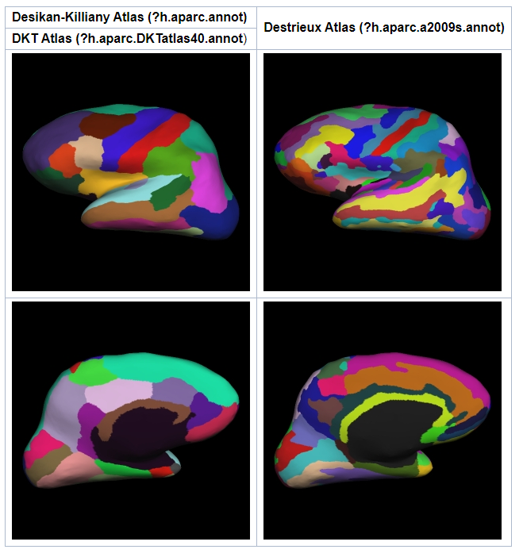

This document contains:

1. Use FreeSurfer annotation files to find out which vertex is assigned to which region. This is repeated in DK and Destrieux annotation files.
2. Merge vertex-wise assignment information between the two atlases.
3. Work out which Destrieux regions overlap with DK regions, and the percentage of region overlap.
4. Infer DK region based on Destrieux data alone, and compare against real DK region (illustrated using the left transversetemporal).

# 1. Build a table associating vertices with labels in DK

## 1.1 Load libraries

```r
library(pander)
library(freesurferformats)
library(knitr)
library(stringr)
library(data.table)
library(plyr)
library(freesurfer)
```

## 1.2 Read in annotation file for Desikan-Killiany

```r
annot = read.fs.annot("C:/Users/k1894405/OneDrive - King's College London/temp/lh.aparc.annot")
```

These annotation files are included in the FreeSurfer software package when you download it. They have an inherent structure and I’ve found it helpful to display the structure with `str(annot)` to understand what it contains. Put simply, it assigns vertices to regions-of-interest (ROIs) that are characterised by numeric codes and a specific color for visualisation.

## 1.3 Display properties contained in annotation file

```r
# show color table and regions
ctable = annot$colortable$table;
regions = annot$colortable$struct_names;
for (region_idx in seq_len(annot$colortable$num_entries)) {
  cat(sprintf("Region #%d called '%s' has code '%d'.\n", region_idx, regions[region_idx], ctable[region_idx,5]));
}
```

```
## Region #1 called 'unknown' has code '1639705'.
## Region #2 called 'bankssts' has code '2647065'.
## Region #3 called 'caudalanteriorcingulate' has code '10511485'.
## Region #4 called 'caudalmiddlefrontal' has code '6500'.
## Region #5 called 'corpuscallosum' has code '3294840'.
## Region #6 called 'cuneus' has code '6558940'.
## Region #7 called 'entorhinal' has code '660700'.
## Region #8 called 'fusiform' has code '9231540'.
## Region #9 called 'inferiorparietal' has code '14433500'.
## Region #10 called 'inferiortemporal' has code '7874740'.
## Region #11 called 'isthmuscingulate' has code '9180300'.
## Region #12 called 'lateraloccipital' has code '9182740'.
## Region #13 called 'lateralorbitofrontal' has code '3296035'.
## Region #14 called 'lingual' has code '9211105'.
## Region #15 called 'medialorbitofrontal' has code '4924360'.
## Region #16 called 'middletemporal' has code '3302560'.
## Region #17 called 'parahippocampal' has code '3988500'.
## Region #18 called 'paracentral' has code '3988540'.
## Region #19 called 'parsopercularis' has code '9221340'.
## Region #20 called 'parsorbitalis' has code '3302420'.
## Region #21 called 'parstriangularis' has code '1326300'.
## Region #22 called 'pericalcarine' has code '3957880'.
## Region #23 called 'postcentral' has code '1316060'.
## Region #24 called 'posteriorcingulate' has code '14464220'.
## Region #25 called 'precentral' has code '14423100'.
## Region #26 called 'precuneus' has code '11832480'.
## Region #27 called 'rostralanteriorcingulate' has code '9180240'.
## Region #28 called 'rostralmiddlefrontal' has code '8204875'.
## Region #29 called 'superiorfrontal' has code '10542100'.
## Region #30 called 'superiorparietal' has code '9221140'.
## Region #31 called 'superiortemporal' has code '14474380'.
## Region #32 called 'supramarginal' has code '1351760'.
## Region #33 called 'frontalpole' has code '6553700'.
## Region #34 called 'temporalpole' has code '11146310'.
## Region #35 called 'transversetemporal' has code '13145750'.
## Region #36 called 'insula' has code '2146559'.
```

## 1.4 Summarise per-vertex info in table

We aim to extract a table that outlines which vertex is assigned to which region.

```r
regions = annot$colortable$struct_names
ctable = annot$colortable$table
names_and_codes<-data.frame(name=NULL,code=NULL)

for (region_idx in seq_len(annot$colortable$num_entries)) {
        names_and_codes[region_idx,"name"]<-regions[region_idx]
        names_and_codes[region_idx,"codes"]<-ctable[region_idx,5]
}


# I would like a table with three rows:
# vertex_idx, label_codes, and corresponding names
vertex_by_region<-data.frame(vertices=annot$vertices,label_codes=annot$label_codes)

# create a new variables that holds the region_name associated with this vertex
vertex_by_region$region_name<-0

cd<-as.numeric(unique(vertex_by_region$label_codes))
# some vertices have not been assigned to any label
cd<-cd[which(cd !=0)]
# if I remove it I have 34 labels left which is correct for DK atlas

for(i in cd){
  vertex_by_region[which(vertex_by_region$label_codes == i),"region_name"]<-names_and_codes[which(names_and_codes$codes == i),"name"]
}


pander(head(vertex_by_region))
```

| vertices | label_codes | region_name |
| --- | --- | --- |
| 0 | 14423100 | precentral |
| 1 | 9221140 | superiorparietal |
| 2 | 10542100 | superiorfrontal |
| 3 | 8204875 | rostralmiddlefrontal |
| 4 | 14423100 | precentral |
| 5 | 1351760 | supramarginal |

As this table contains 163842 rows, it’s too big to display entirely; only printing the head of the table.

The vertices are in standard fsaverage space. ROIs can be constructed as the sum of all the vertices that fall into an area. ?h.area, ?h.volume, and ?h.thickness contain the per-vertex value for either area, volume or thickness. When I started playing with the annotation files I wanted to re-construct Destrieux IDPs (imaging derived-phenotypes) from DK IDPs, which is not the most accurate or sensible way, but I didn’t realise it then.

# 2. Repeat the same thing for the Destrieux atlas

## 2.1 Read in annotation file for Destrieux

```r
desannot = read.fs.annot("C:/Users/k1894405/OneDrive - King's College London/temp/lh.aparc.a2009s.annot")
```

## 2.2 Diplay properties contained in this file

```r
ctable = desannot$colortable$table;
regions = desannot$colortable$struct_names;
for (region_idx in seq_len(desannot$colortable$num_entries)) {
  cat(sprintf("Region #%d called '%s' has code '%d'.\n", region_idx, regions[region_idx], ctable[region_idx,5]));
}
```

```
## Region #1 called 'Unknown' has code '0'.
## Region #2 called 'G_and_S_frontomargin' has code '3988503'.
## Region #3 called 'G_and_S_occipital_inf' has code '11811863'.
## Region #4 called 'G_and_S_paracentral' has code '3957823'.
## Region #5 called 'G_and_S_subcentral' has code '14423103'.
## Region #6 called 'G_and_S_transv_frontopol' has code '16384013'.
## Region #7 called 'G_and_S_cingul-Ant' has code '15386'.
## Region #8 called 'G_and_S_cingul-Mid-Ant' has code '4930586'.
## Region #9 called 'G_and_S_cingul-Mid-Post' has code '9845786'.
## Region #10 called 'G_cingul-Post-dorsal' has code '16399385'.
## Region #11 called 'G_cingul-Post-ventral' has code '1644860'.
## Region #12 called 'G_cuneus' has code '1316020'.
## Region #13 called 'G_front_inf-Opercular' has code '6558940'.
## Region #14 called 'G_front_inf-Orbital' has code '3947660'.
## Region #15 called 'G_front_inf-Triangul' has code '9231540'.
## Region #16 called 'G_front_middle' has code '11822220'.
## Region #17 called 'G_front_sup' has code '9180340'.
## Region #18 called 'G_Ins_lg_and_S_cent_ins' has code '657943'.
## Region #19 called 'G_insular_short' has code '9211105'.
## Region #20 called 'G_occipital_middle' has code '11812020'.
## Region #21 called 'G_occipital_sup' has code '3988500'.
## Region #22 called 'G_oc-temp_lat-fusifor' has code '9180220'.
## Region #23 called 'G_oc-temp_med-Lingual' has code '9221340'.
## Region #24 called 'G_oc-temp_med-Parahip' has code '1336385'.
## Region #25 called 'G_orbital' has code '1326300'.
## Region #26 called 'G_pariet_inf-Angular' has code '14433300'.
## Region #27 called 'G_pariet_inf-Supramar' has code '3957860'.
## Region #28 called 'G_parietal_sup' has code '14464220'.
## Region #29 called 'G_postcentral' has code '9221140'.
## Region #30 called 'G_precentral' has code '11832380'.
## Region #31 called 'G_precuneus' has code '9180185'.
## Region #32 called 'G_rectus' has code '6568980'.
## Region #33 called 'G_subcallosal' has code '1367100'.
## Region #34 called 'G_temp_sup-G_T_transv' has code '14433340'.
## Region #35 called 'G_temp_sup-Lateral' has code '14433500'.
## Region #36 called 'G_temp_sup-Plan_polar' has code '3988545'.
## Region #37 called 'G_temp_sup-Plan_tempo' has code '1346585'.
## Region #38 called 'G_temporal_inf' has code '6610140'.
## Region #39 called 'G_temporal_middle' has code '3947700'.
## Region #40 called 'Lat_Fis-ant-Horizont' has code '14423101'.
```

[output cut: 21 more lines]

```
## Region #62 called 'S_oc-temp_lat' has code '1346781'.
## Region #63 called 'S_oc-temp_med_and_Lingual' has code '14443661'.
## Region #64 called 'S_orbital_lateral' has code '1336541'.
## Region #65 called 'S_orbital_med-olfact' has code '1362101'.
## Region #66 called 'S_orbital-H_Shaped' has code '1315941'.
## Region #67 called 'S_parieto_occipital' has code '11822181'.
## Region #68 called 'S_pericallosal' has code '1367221'.
## Region #69 called 'S_postcentral' has code '13143061'.
## Region #70 called 'S_precentral-inf-part' has code '15733781'.
## Region #71 called 'S_precentral-sup-part' has code '13112341'.
## Region #72 called 'S_suborbital' has code '3937301'.
## Region #73 called 'S_subparietal' has code '3947621'.
## Region #74 called 'S_temporal_inf' has code '11842581'.
## Region #75 called 'S_temporal_sup' has code '3988703'.
## Region #76 called 'S_temporal_transverse' has code '3947741'.
```

Same here: we have the 74 Destrieux regions + the corpus callosum and an unknown category.

## 2.3 Extract Destrieux information

```r
# each label code stands for a region
regions = desannot$colortable$struct_names
ctable = desannot$colortable$table
names_and_codes<-data.frame(name=NULL,code=NULL)

for (region_idx in seq_len(desannot$colortable$num_entries)) {
  names_and_codes[region_idx,"name"]<-regions[region_idx]
  names_and_codes[region_idx,"codes"]<-ctable[region_idx,5]
}

# I would like a table with three rows:
# vertex_idx, label_codes, and corresponding names
des_vertex_by_region<-data.frame(vertices=desannot$vertices,label_codes=desannot$label_codes)
des_vertex_by_region$region_name<-0

cd<-as.numeric(unique(des_vertex_by_region$label_codes))
# somehow this contains a zero which does not represent a valid label code
cd<-cd[which(cd !=0)]
# if I remove it I have only 74 labels left which is correct for Destrieux atlas

for(i in cd){
  des_vertex_by_region[which(des_vertex_by_region$label_codes == i),"region_name"]<-names_and_codes[which(names_and_codes$codes == i),"name"]
}

pander(head(des_vertex_by_region))
```

| vertices | label_codes | region_name |
| --- | --- | --- |
| 0 | 11832380 | G_precentral |
| 1 | 14464220 | G_parietal_sup |
| 2 | 9845786 | G_and_S_cingul-Mid-Post |
| 3 | 6558861 | S_front_middle |
| 4 | 14423103 | G_and_S_subcentral |
| 5 | 3957860 | G_pariet_inf-Supramar |

# 3. Merge the atlases by vertices

We can now match the two atlases by vertex, as they should both be in fsaverage space.

## 3.1 Display head of file with matched atlases

```r
# rename columns to know which atlas they belong to
names(vertex_by_region)<-c("vertices","DK_label_codes","DK_region_name")
names(des_vertex_by_region)<-c("vertices","Destrieux_label_codes","Destrieux_region_name")

# merge the files by vertices
both<-merge(des_vertex_by_region,vertex_by_region,by="vertices")

pander(head(both))
```

Table continues below

| vertices | Destrieux_label_codes | Destrieux_region_name | DK_label_codes |
| --- | --- | --- | --- |
| 0 | 11832380 | G_precentral | 14423100 |
| 1 | 14464220 | G_parietal_sup | 9221140 |
| 2 | 9845786 | G_and_S_cingul-Mid-Post | 10542100 |
| 3 | 6558861 | S_front_middle | 8204875 |
| 4 | 14423103 | G_and_S_subcentral | 14423100 |
| 5 | 3957860 | G_pariet_inf-Supramar | 1351760 |

| DK_region_name |
| --- |
| precentral |
| superiorparietal |
| superiorfrontal |
| rostralmiddlefrontal |
| precentral |
| supramarginal |

## 3.2 Display Destrieux regions that fall into each DK region

```r
#select the unique regions in DK
unique_DK_region<-unique(both$DK_region_name)
# delete unknown category and corpus callosum
unique_DK_region<-unique_DK_region[unique_DK_region!="unknown" & unique_DK_region!="0"]
# 34 DK regions left

number_matches<-0

for(i in unique_DK_region){
  match_region<-NULL
  match_region<-prop.table(table(both[which(both$DK_region_name == i),"Destrieux_region_name"]))
  # restructure
  match_region<-reshape2::melt(match_region)
  names(match_region)<-c("Destrieux_region_name","percent_DK")

  number_matches<-number_matches+nrow(match_region)

  # break the code if the sum of percentages that make up a region is not equal to 1
  if(isFALSE(all.equal(1,sum(match_region$percent_DK)))){print("Your percentages do not add up to 1!");break}

  var_name<-paste0("match_",i)
  assign(var_name,match_region)
}

# print results
rm("match_region")
all_match<-ls(pattern="match_")
# make sure we have 34 regions
if(length(all_match)!=34){print("We did not end up with the correct number of DKT regions"); break} # break with 31 regions in DKT, DK 34 regions


kable(match_entorhinal,caption = "Example: Which areas is the entorhinal made up of?")
```

Example: Which areas is the entorhinal made up of?

| Destrieux_region_name | percent_DK |
| --- | --- |
| G_oc-temp_med-Parahip | 0.8774955 |
| Pole_temporal | 0.1225045 |

## 3.3 Work out percentages of Destrieux regions that fall into each DK region

```r
# table to store all
all_percentages<-as.data.frame(matrix(nrow=0, ncol=3))
names(all_percentages) =c("DK_region","Des_region","percent")


# all saved in all_match
for (i in all_match){
  # get table containing regions
  match<-get(i)
  match<-as.data.frame(match)
  # name DK_region of interest DK_region
  DK_region<-str_remove_all(i,"match_")

  # save match and DK_region alongside another in all_percentages
  all_percentages=rbind(all_percentages, cbind(DK_region, match))

}

DT::datatable(all_percentages, rownames=FALSE, filter="top",options= list(pageLength=10,scrollX=T), caption = "Percentages of Destrieux regions that fall into DK region")
```

| DK_region | Destrieux_region_name | percent_DK |
| --- | --- | --- |
| bankssts | G_pariet_inf-Angular | 0.000467945718296678 |
| bankssts | G_temp_sup-Lateral | 0.168460458586804 |
| bankssts | G_temporal_middle | 0.0524099204492279 |
| bankssts | S_temporal_sup | 0.778661675245672 |
| caudalanteriorcingulate | G_and_S_cingul-Ant | 0.0882557331480195 |
| caudalanteriorcingulate | G_and_S_cingul-Mid-Ant | 0.542043085476025 |
| caudalanteriorcingulate | G_and_S_cingul-Mid-Post | 0.00138985406532314 |
| caudalanteriorcingulate | S_pericallosal | 0.368311327310632 |
| caudalmiddlefrontal | G_front_middle | 0.419432548179872 |
| caudalmiddlefrontal | G_precentral | 0.019271948608137 |

[output cut: 229 more lines]

# 4. Can I apply this idea meaningfully to individual level data?

I tried to display the DK atlas purely based on information contained in the Destrieux atlas. The code can easily be adapted to infer all regions in a loop but there would not be space to display it here. So, for the purpose of this document I only display the left transversetemporal.

## 4.1 Surface Area

```r
rm(list = setdiff(ls(), "all_percentages"))
# all_percentages only contains left hemispehere
all_percentages$DK_region = paste0("lh.",all_percentages$DK_region)
all_percentages$Destrieux_region_name = paste0("lh.",all_percentages$Destrieux_region_name)
# whenever "-" is used, R gets confused
all_percentages$DK_region = str_replace(all_percentages$DK_region, pattern="-", replacement = ".")
all_percentages$Destrieux_region_name = str_replace(all_percentages$Destrieux_region_name, pattern="-", replacement = ".")

# read in real Destrieux file
Des_surfarea = fread("C:/Users/k1894405/OneDrive - King's College London/temp/Des_SurfArea_all", nrows = 1000)

# chose DK region to infer from Des
testregion = "lh.transversetemporal"
# get percentages to which Des regions overlap with DK
statsregion = all_percentages[which(all_percentages$DK_region == testregion),]
# get formula: weighted sum of Des regions that make up DK
formula = with(statsregion, paste0("(",percent_DK," * Des_surfarea$",Destrieux_region_name, ")", collapse = " + "))
fulleq <- paste0('DK_inferred', ' <- ', formula)
# execute formula
eval(parse(text=fulleq))
# merge inferred region with IIDs
merged = as.data.frame(cbind(Des_surfarea$IID, DK_inferred))
names(merged) = c("IID","inferred")

# read in real DK file
DK_surfarea = fread("C:/Users/k1894405/OneDrive - King's College London/temp/DK_SurfArea_all", nrows = 1000)
# keep relevant column only
DK_surfarea = subset(DK_surfarea, select = c("IID", testregion))

# merge inferred with real area
merged = merge(DK_surfarea, merged, by = "IID")

names(merged) = c("IID", "real", "inferred")
# plot
plot(merged$real, merged$inferred, main = paste("Inferred surface area:",testregion))
abline(a=0, b=1, col="red")
```

[figure not shown]

The inferred estimate seems to overestimate the region size this way.

## 4.2 Grey-matter volume

```r
rm(list = setdiff(ls(), "all_percentages"))


# read in real Destrieux file
Des_volume = fread("C:/Users/k1894405/OneDrive - King's College London/temp/Des_GrayVol_all", nrows = 1000)

# chose DK region to infer from Des
testregion = "lh.transversetemporal"
# get percentages to which Des regions overlap with DK
statsregion = all_percentages[which(all_percentages$DK_region == testregion),]
# get formula: weighted sum of Des regions that make up DK
formula = with(statsregion, paste0("(",percent_DK," * Des_volume$",Destrieux_region_name, ")", collapse = " + "))
fulleq <- paste0('DK_inferred', ' <- ', formula)
# execute formula
eval(parse(text=fulleq))
# merge inferred region with IIDs
merged = as.data.frame(cbind(Des_volume$IID, DK_inferred))
names(merged) = c("IID","inferred")

# read in real DK file
DK_volume = fread("C:/Users/k1894405/OneDrive - King's College London/temp/DK_GrayVol_all", nrows = 1000)
# keep relevant column only
DK_volume = subset(DK_volume, select = c("IID", testregion))

# merge inferred with real area
merged = merge(DK_volume, merged, by = "IID")

names(merged) = c("IID", "real", "inferred")
# plot
plot(merged$real, merged$inferred, main = paste("Inferred volume:",testregion))
abline(a=0, b=1, col="red")
```

[figure not shown]

## 4.3 Cortical thickness

```r
rm(list = setdiff(ls(), "all_percentages"))


# read in real Destrieux file
Des_thickness = fread("C:/Users/k1894405/OneDrive - King's College London/temp/Des_ThickAvg_all", nrows = 1000)

# chose DK region to infer from Des
testregion = "lh.transversetemporal"
# get percentages to which Des regions overlap with DK
statsregion = all_percentages[which(all_percentages$DK_region == testregion),]
# get formula: weighted sum of Des regions that make up DK
formula = with(statsregion, paste0("(",percent_DK," * Des_thickness$",Destrieux_region_name, ")", collapse = " + "))
fulleq <- paste0('DK_inferred', ' <- ', formula)
# execute formula
eval(parse(text=fulleq))
# merge inferred region with IIDs
merged = as.data.frame(cbind(Des_thickness$IID, DK_inferred))
names(merged) = c("IID","inferred")

# read in real DK file
DK_thickness = fread("C:/Users/k1894405/OneDrive - King's College London/temp/DK_ThickAvg_all", nrows = 1000)
# keep relevant column only
DK_thickness = subset(DK_thickness, select = c("IID", testregion))

# merge inferred with real area
merged = merge(DK_thickness, merged, by = "IID")

names(merged) = c("IID", "real", "inferred")
# plot
plot(merged$real, merged$inferred, main = paste("Inferred thickness:",testregion))
abline(a=0, b=1, col="red")
```

[figure not shown]

In all cases the inferred volume seems to be overestimated.

This is not the appropriate way of doing it anyway, but I learned a lot from playing with the parcellation files. I ended up using properly established protocols to map different brain atlases onto my participants data.

[figure not shown]

By Anna Elisabeth Fürtjes

*anna.furtjes@kcl.ac.uk*